# a-bST 회수 공정 최적화를 통한 원상화 수율 증대_Rev.01

# ■ Define

### Step01 개선 기회 탐색

- 정보화된 시스템 중 어느 시스템을 통해 개선 기회를 수시 점검 및 발굴 할 수 있는가?

### Step02 개선 기회 발굴 및 과제 선정

- 부스틴 발효 - 회수 공정을 최적화함
- 목표 : 평균 수율 70% → 72%

### Step03 Project Y 선정

- Project Y : 원상화(Refolding) (DP-0T) Yield 증대
- 한외여과 공정 OT_UF OT 총량(kg) / 회수공정(X2) _ RWP(kg) x 100

# ■ Measure

### Step04 데이터 수집 및 검증 계획 수립

Data 수집 계획 :

- 측정 지표 : 공정 파라미터
- 수집 시스템 : 엔지니어 공정데이터 수기 취합 (MES 예정)
- 수집 기간 : 19년01월 ~ 20년05월
- 변수 : 27ea

### Step05 데이터 Set 구성

- 데이터 형식 Numeric 확인함

```r
library(readxl)
Booster = read_excel("DAT/Booster_Rev.01.xlsx", sheet = 'sheet_03',  skip=2)
str(Booster)
```

```
## tibble [112 x 27] (S3: tbl_df/tbl/data.frame)
##  $ A : chr [1:112] "BSP19004" "BSP19005" "BSP19006" "BSP19007" ...
##  $ F : num [1:112] 71 64 74 80 74 75 72 76 81 73 ...
##  $ H : num [1:112] 130 131 131 129 132 ...
##  $ I : num [1:112] 94.4 94.5 95.1 94.4 94.8 94.9 94.6 94.9 94.7 94.8 ...
##  $ J : num [1:112] 0.6 0.67 0.59 0.56 0.61 0.67 0.64 0.66 0.68 0.66 ...
##  $ K : num [1:112] 92.6 95.8 91 89.1 83.8 ...
##  $ L : num [1:112] 41.9 37.1 38.9 42.3 37.2 ...
##  $ M : num [1:112] 45.2 38.8 42.7 47.5 44.4 ...
##  $ N : num [1:112] 98.9 97.9 98.9 98.8 99 98.2 98 98.9 96.5 98.3 ...
##  $ O : num [1:112] 49.3 51.5 51.5 49.8 57.5 51.5 47 49.3 50.2 45.8 ...
##  $ P : num [1:112] 88.4 89.9 88.4 87.1 84.9 ...
##  $ Q : num [1:112] 95.5 93.8 97.1 97.7 101.2 ...
##  $ R : num [1:112] 70.8 70.2 71.2 69.9 66.5 ...
##  $ T : num [1:112] 80 78.1 80.5 80.3 78.4 ...
##  $ U : num [1:112] 98.7 98.7 98.8 98.7 98.8 98.7 98.6 98.6 98.7 98.2 ...
##  $ V : num [1:112] 27.2 28.9 26.5 28.4 23.8 ...
##  $ W : num [1:112] 67.8 67.8 69.5 64 64 ...
##  $ Z : num [1:112] 98.6 98.6 98.7 98.7 98.8 98.7 98.5 98.6 93.9 97.4 ...
##  $ AA: num [1:112] 81.2 83.2 88.2 79.8 84 ...
##  $ AB: num [1:112] 2.9 3.2 3.4 2.8 2.6 3.1 3.4 3.7 3.6 2.5 ...
##  $ AC: num [1:112] 5.7 6.4 7 6.8 6 5.7 6.1 6.3 6.1 8.8 ...
##  $ AE: num [1:112] 80.8 79.4 77.9 80.5 76.6 78.5 78.3 76.6 78 76.4 ...
##  $ AG: num [1:112] 35.3 32.8 36.5 39.5 35 ...
##  $ AH: num [1:112] 98 97.5 97 97.7 97.2 97.6 97.4 96.7 97.2 97.8 ...
##  $ AI: num [1:112] 62.1 64.5 60.7 56.4 54 ...
##  $ AJ: num [1:112] 97.2 96.7 96.5 97.1 96.4 97.1 96.9 96.1 95.9 96.5 ...
##  $ AK: num [1:112] 30 30 30 33 34 32 30 30 30 30 ...
```

Dataset 의 Column 이름을 확인하고, 데이터 복사본을 생성함.

```r
library(dplyr)
colnames(Booster)
```

```
##  [1] "A"  "F"  "H"  "I"  "J"  "K"  "L"  "M"  "N"  "O"  "P"  "Q"  "R"  "T"  "U"
## [16] "V"  "W"  "Z"  "AA" "AB" "AC" "AE" "AG" "AH" "AI" "AJ" "AK"
```

```r
df <- Booster
```

종속변수인 원상화 Yield 개략적인 데이터 분포를 확인함

- Project Y : 원상화(Refolding) (DP-0T) Yield
- Project Y 산출 공식 : 한외여과 공정 OT_UF OT 총량(kg) / 회수공정(X2) _ RWP(kg) x 100
- Project Y 산출 공식 : 변수 K / 변수 H x 100
- Project Y 변수명을 BB 라 명명함

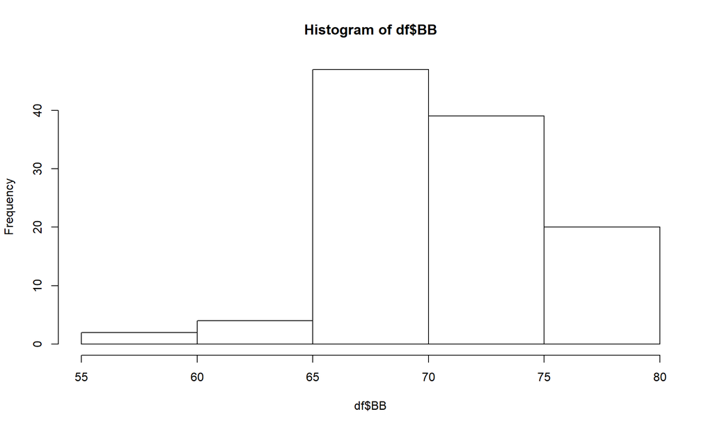

```r
df <- df %>%
  mutate(BB = K / H * 100)

hist(df$BB)
```

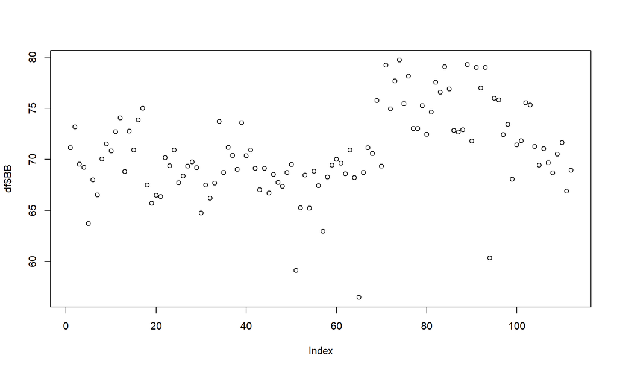

```r
plot(df$BB)
```

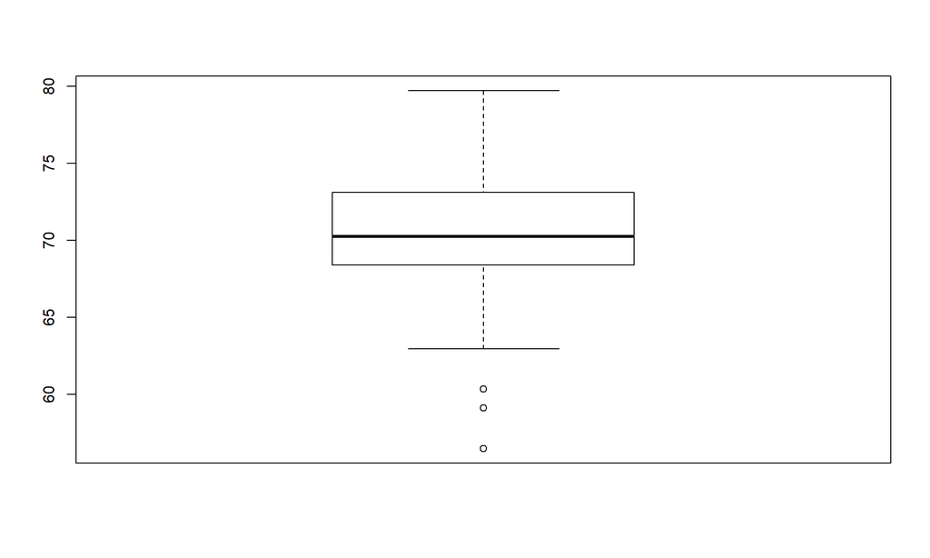

```r
boxplot(df$BB)
```

```r
summary(df$BB)
```

```
##    Min. 1st Qu.  Median    Mean 3rd Qu.    Max.
##   56.47   68.43   70.26   70.72   73.07   79.74
```

### Step06 데이터 취득 시스템(유용성)검증

### Step07 프로세스 현수준 파악

- Install.packages() 는 최초 1회 설치 후 주석처리 하도록 함.
- R Markdown 에 Install.packages() 가 포함되어 있으면 knit 할 때마다 해당 패키지가 신규 설치됨

```r
#Install.packages(SixSigma)
library(SixSigma)
```

[output not shown]

- Plots a Histogram with density lines.
- Usage : ss.study.ca(xST, xLT = NA, LSL = NA, USL = NA, Target = NA)
- P-value 가 0.05보다 작으므로 정규분포한다고 보기 어려움

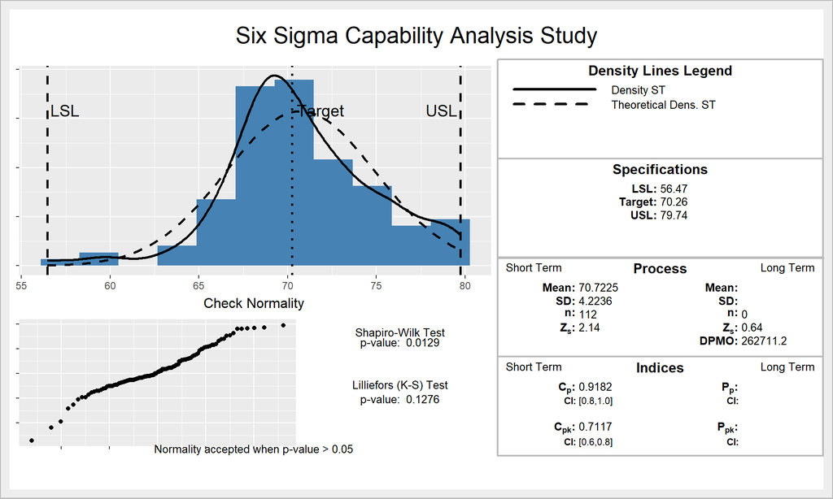

```r
ss.study.ca(xST=df$BB, LSL =56.47, USL =79.74, Target = 70.26)
```

### Step08 개선 목표 설정

- 원상화 수율 평균 70.72% (Z bench 2.14) → 평균 72% 이상

# ■ Analyze

### Step09 X인자 검증 계획 수립

데이터 수집 계획

- project Y : BB data - LIMS 자동 Collecting
- x’s : 공정 Parameter Data MES 자동 Collecting

### Step10 데이터 취득 및 전처리 실시

전처리 도구 불러오기

- 부스틴 생산팀(이형중 팀장님) 에서 수기로 기록한 데이터(.xlsx)를 분석함
- Project Y 는 파생변수 BB 추가함

```r
library(dplyr);library(tidyr)
```

### Step11 데이터 탐색

데이터 요약

```r
summary(df)
```

```
##       A                   F                H               I
##  Length:112         Min.   : 64.00   Min.   :101.5   Min.   : 93.20
##  Class :character   1st Qu.: 76.00   1st Qu.:115.5   1st Qu.: 94.80
##  Mode  :character   Median : 84.00   Median :122.8   Median : 95.00
##                     Mean   : 83.02   Mean   :122.5   Mean   : 96.29
##                     3rd Qu.: 89.25   3rd Qu.:130.9   3rd Qu.:100.00
##                     Max.   :106.00   Max.   :154.7   Max.   :100.00
##        J                K               L               M
##  Min.   :0.1400   Min.   :66.80   Min.   :34.26   Min.   :38.50
##  1st Qu.:0.1800   1st Qu.:82.83   1st Qu.:40.40   1st Qu.:46.95
##  Median :0.5500   Median :87.77   Median :44.05   Median :51.74
##  Mean   :0.4430   Mean   :86.43   Mean   :44.97   Mean   :52.11
##  3rd Qu.:0.6225   3rd Qu.:91.30   3rd Qu.:50.02   3rd Qu.:56.75
##  Max.   :0.7600   Max.   :98.84   Max.   :58.44   Max.   :71.65
##        N               O               P               Q
##  Min.   :95.90   Min.   :21.10   Min.   :67.24   Min.   : 83.80
##  1st Qu.:97.70   1st Qu.:47.67   1st Qu.:78.10   1st Qu.: 93.89
##  Median :98.40   Median :49.45   Median :84.25   Median : 95.60
##  Mean   :98.18   Mean   :49.63   Mean   :82.84   Mean   : 95.97
##  3rd Qu.:98.70   3rd Qu.:51.70   3rd Qu.:86.79   3rd Qu.: 97.59
##  Max.   :99.10   Max.   :64.60   Max.   :95.90   Max.   :115.38
##        R               T               U               V
##  Min.   :54.66   Min.   :75.70   Min.   :94.10   Min.   :14.68
##  1st Qu.:66.71   1st Qu.:80.51   1st Qu.:97.17   1st Qu.:23.70
##  Median :69.57   Median :83.20   Median :98.20   Median :25.00
##  Mean   :68.66   Mean   :82.95   Mean   :97.74   Mean   :25.32
##  3rd Qu.:71.54   3rd Qu.:85.25   3rd Qu.:98.60   3rd Qu.:27.10
##  Max.   :78.40   Max.   :89.83   Max.   :98.80   Max.   :31.60
##        W               Z               AA              AB
##  Min.   :53.00   Min.   :79.40   Min.   :56.50   Min.   :0.300
##  1st Qu.:63.81   1st Qu.:92.17   1st Qu.:77.44   1st Qu.:2.900
##  Median :67.69   Median :97.40   Median :83.88   Median :3.500
##  Mean   :67.12   Mean   :95.47   Mean   :83.00   Mean   :3.879
##  3rd Qu.:71.00   3rd Qu.:98.25   3rd Qu.:89.06   3rd Qu.:4.800
##  Max.   :81.75   Max.   :98.80   Max.   :94.50   Max.   :7.500
##        AC               AE              AG              AH
##  Min.   : 4.700   Min.   :74.30   Min.   :17.54   Min.   :96.00
##  1st Qu.: 6.000   1st Qu.:77.70   1st Qu.:27.98   1st Qu.:97.20
##  Median : 6.500   Median :79.10   Median :33.59   Median :97.60
##  Mean   : 6.873   Mean   :78.98   Mean   :34.30   Mean   :97.55
##  3rd Qu.: 7.300   3rd Qu.:80.10   3rd Qu.:38.86   3rd Qu.:97.90
##  Max.   :13.300   Max.   :83.40   Max.   :52.80   Max.   :98.80
##        AI              AJ              AK              BB
##  Min.   :42.26   Min.   :95.60   Min.   :20.00   Min.   :56.47
##  1st Qu.:50.37   1st Qu.:96.40   1st Qu.:28.00   1st Qu.:68.43
##  Median :56.00   Median :96.85   Median :30.00   Median :70.26
##  Mean   :55.64   Mean   :96.78   Mean   :29.81   Mean   :70.72
##  3rd Qu.:60.92   3rd Qu.:97.20   3rd Qu.:32.00   3rd Qu.:73.07
##  Max.   :67.87   Max.   :97.90   Max.   :95.80   Max.   :79.74
```

Graph분석

- 변수 A는 배치 번호이므로 제외함

```r
df2 <- df %>% select(-A)
df_cor <- cor(df2)
df_cor
```

```
##              F           H           I           J           K           L
## F   1.00000000  0.08792944  0.25345957 -0.30181091  0.29160302  0.35238919
## H   0.08792944  1.00000000 -0.04222428  0.21560225  0.74272524 -0.03915396
## I   0.25345957 -0.04222428  1.00000000 -0.78039121  0.20681754  0.58198185
## J  -0.30181091  0.21560225 -0.78039121  1.00000000 -0.15904370 -0.72311311
## K   0.29160302  0.74272524  0.20681754 -0.15904370  1.00000000  0.41712551
## L   0.35238919 -0.03915396  0.58198185 -0.72311311  0.41712551  1.00000000
## M   0.20818914 -0.50964306  0.49121096 -0.67719725 -0.17102584  0.82233425
## N  -0.06330307  0.21424001 -0.14475171  0.20748305 -0.08688698 -0.41690076
## O  -0.34896263  0.07556318 -0.08902780  0.18718175 -0.08890046 -0.35229858
## P   0.22411568  0.73461605  0.16299492 -0.15193688  0.89413233  0.33075007
## Q  -0.20074433 -0.18777648 -0.13814158  0.05886709 -0.46041057 -0.27581376
## R   0.22362913  0.52944443  0.33873831 -0.35240575  0.81718645  0.63190691
## T  -0.02990163 -0.45335748  0.29256256 -0.33657543 -0.23079630  0.51350254
## U  -0.22809547  0.28669862 -0.41445397  0.60003294 -0.03308766 -0.45428887
## V   0.08970552  0.27567661  0.02152454 -0.05982371  0.22826829 -0.24020151
## W   0.24129403  0.51634877  0.44083072 -0.34140941  0.71253060  0.57741167
## Z  -0.09848796  0.12122342 -0.33631750  0.33316764 -0.05411270 -0.40523309
## AA  0.16255433  0.58849317  0.47200109 -0.27671647  0.63637229  0.30547165
## AB  0.36232116 -0.11539257  0.61774678 -0.63234892  0.10666362  0.49933072
## AC  0.10387787 -0.28545896 -0.01874180 -0.23601519  0.01493188  0.38358911
## AE  0.05361911  0.07503149  0.49742998 -0.50915459  0.19750125  0.38461525
## AG  0.25404808  0.38674480  0.64481222 -0.50373410  0.47721132  0.42244201
## AH  0.15112976 -0.26280634  0.47918180 -0.52620911 -0.10491866  0.21383559
## AI  0.10903575  0.55540327  0.49138908 -0.22549620  0.62311597  0.33632198
## AJ  0.03160403 -0.18863852  0.49677709 -0.47777979 -0.10699240  0.15942951
## AK -0.06152935  0.11475863 -0.50702379  0.44847687  0.07098057 -0.27342109
## BB  0.26981051 -0.48023091  0.34036430 -0.54306204  0.22645353  0.62809666
##               M           N            O            P            Q           R
## F   0.208189143 -0.06330307 -0.348962633  0.224115682 -0.200744332  0.22362913
## H  -0.509643061  0.21424001  0.075563176  0.734616053 -0.187776480  0.52944443
## I   0.491210960 -0.14475171 -0.089027802  0.162994922 -0.138141584  0.33873831
## J  -0.677197254  0.20748305  0.187181752 -0.151936877  0.058867095 -0.35240575
## K  -0.171025843 -0.08688698 -0.088900455  0.894132331 -0.460410573  0.81718645
## L   0.822334251 -0.41690076 -0.352298580  0.330750072 -0.275813762  0.63190691
## M   1.000000000 -0.39295793 -0.336797725 -0.196767834 -0.009687366  0.17747218
## N  -0.392957934  1.00000000  0.160195061 -0.045800264  0.111629559 -0.17799147
## O  -0.336797725  0.16019506  1.000000000 -0.003631428  0.172989976 -0.06657125
## P  -0.196767834 -0.04580026 -0.003631428  1.000000000 -0.018466928  0.86402716
## Q  -0.009687366  0.11162956  0.172989976 -0.018466928  1.000000000 -0.12404770
```

[output cut: 85 more lines]

```
## T   0.03730532 -0.17401146  0.37201911
## U  -0.23220887  0.29458984 -0.47110451
## V   0.10014996  0.02303949 -0.11354878
## W  -0.06338021 -0.11632584  0.18769531
## Z  -0.05433157  0.23612418 -0.27475205
## AA  0.06666663 -0.16482975 -0.02566249
## AB  0.22858917 -0.39432907  0.32165465
## AC -0.26149753  0.03182668  0.46658666
## AE  0.47852771 -0.43204065  0.14547438
## AG  0.26651213 -0.30107786  0.06336076
## AH  0.89863510 -0.42676183  0.23851415
## AI  0.20821361 -0.20915979 -0.00620266
## AJ  1.00000000 -0.38560941  0.12196139
## AK -0.38560941  1.00000000 -0.08115451
## BB  0.12196139 -0.08115451  1.00000000
```

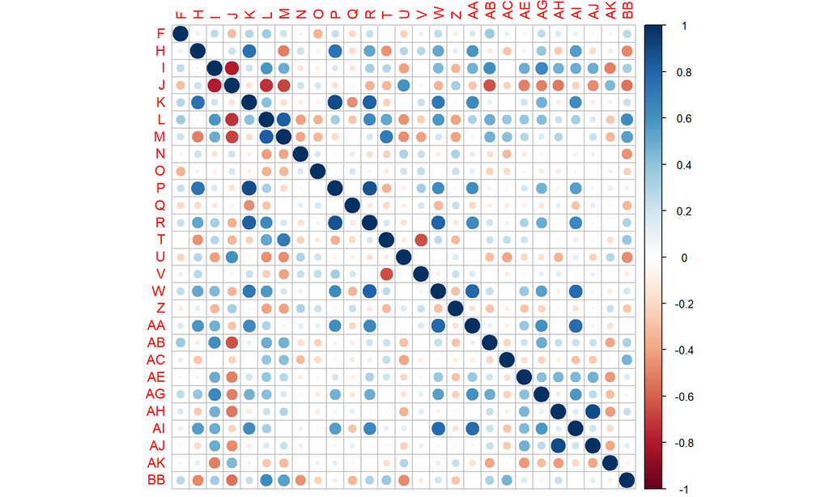

```r
library(corrplot)
corrplot(df_cor)
```

통계적 이상치 제거

```r
dim(df)
```

```
## [1] 112  28
```

```r
df2  <-  df %>% filter(df$BB>boxplot.stats(df$BB)$stats[1], # Q1 - 1.5 * IQR 이하 제거
                       df$BB<boxplot.stats(df$BB)$stats[5]) # Q3 + 1.5 * IQR 이상 제거
df <-  df2

dim(df)
```

```
## [1] 107  28
```

### Step12 핵심인자 선정

데이터 Set 구분하기

- 전체 107 obs. of 28 variables 중에서 70% 는 Train 세트로 설정하고 30% 는 Test 세트로 설정함

set.seed()

- 난수를 생성하는 초기값(seed)를 지정하기 위해 사용하는 함수임.
- 난수를 사용하여 데이터를 분리하므로 매 호출시마다 서로 다른 folds 결과가 출력됨. 하지만 seed를 지정해주면 매번 같은 folds를 결과로 내놓게되어 교차 검증을 수회 반복하더라도 같은 folds를 사용해 안정적으로 모델을 개선할 수 있음.
- set.seed 를 설정하지 않으면 매번 다른 샘플이 추출됨.
- 집주소가 00 아파트 1303호라면 set.seed(1303) 으로 설정해도 무방함.

```r
str(df)
```

```
## tibble [107 x 28] (S3: tbl_df/tbl/data.frame)
##  $ A : chr [1:107] "BSP19004" "BSP19005" "BSP19006" "BSP19007" ...
##  $ F : num [1:107] 71 64 74 80 74 75 72 76 81 73 ...
##  $ H : num [1:107] 130 131 131 129 132 ...
##  $ I : num [1:107] 94.4 94.5 95.1 94.4 94.8 94.9 94.6 94.9 94.7 94.8 ...
##  $ J : num [1:107] 0.6 0.67 0.59 0.56 0.61 0.67 0.64 0.66 0.68 0.66 ...
##  $ K : num [1:107] 92.6 95.8 91 89.1 83.8 ...
##  $ L : num [1:107] 41.9 37.1 38.9 42.3 37.2 ...
##  $ M : num [1:107] 45.2 38.8 42.7 47.5 44.4 ...
##  $ N : num [1:107] 98.9 97.9 98.9 98.8 99 98.2 98 98.9 96.5 98.3 ...
##  $ O : num [1:107] 49.3 51.5 51.5 49.8 57.5 51.5 47 49.3 50.2 45.8 ...
##  $ P : num [1:107] 88.4 89.9 88.4 87.1 84.9 ...
##  $ Q : num [1:107] 95.5 93.8 97.1 97.7 101.2 ...
##  $ R : num [1:107] 70.8 70.2 71.2 69.9 66.5 ...
##  $ T : num [1:107] 80 78.1 80.5 80.3 78.4 ...
##  $ U : num [1:107] 98.7 98.7 98.8 98.7 98.8 98.7 98.6 98.6 98.7 98.2 ...
##  $ V : num [1:107] 27.2 28.9 26.5 28.4 23.8 ...
##  $ W : num [1:107] 67.8 67.8 69.5 64 64 ...
##  $ Z : num [1:107] 98.6 98.6 98.7 98.7 98.8 98.7 98.5 98.6 93.9 97.4 ...
##  $ AA: num [1:107] 81.2 83.2 88.2 79.8 84 ...
##  $ AB: num [1:107] 2.9 3.2 3.4 2.8 2.6 3.1 3.4 3.7 3.6 2.5 ...
##  $ AC: num [1:107] 5.7 6.4 7 6.8 6 5.7 6.1 6.3 6.1 8.8 ...
##  $ AE: num [1:107] 80.8 79.4 77.9 80.5 76.6 78.5 78.3 76.6 78 76.4 ...
##  $ AG: num [1:107] 35.3 32.8 36.5 39.5 35 ...
##  $ AH: num [1:107] 98 97.5 97 97.7 97.2 97.6 97.4 96.7 97.2 97.8 ...
##  $ AI: num [1:107] 62.1 64.5 60.7 56.4 54 ...
##  $ AJ: num [1:107] 97.2 96.7 96.5 97.1 96.4 97.1 96.9 96.1 95.9 96.5 ...
##  $ AK: num [1:107] 30 30 30 33 34 32 30 30 30 30 ...
##  $ BB: num [1:107] 71.1 73.2 69.5 69.2 63.7 ...
```

```r
dim(df)
```

```
## [1] 107  28
```

```r
nrow(df)
```

```
## [1] 107
```

```r
set.seed(1303)
train=sample(nrow(df),nrow(df)*0.7)
test=(1:c(nrow(df)))[-train]
```

Train 세트와 Test 세트의 데이터 프레임을 확인함

```r
length(train) # 전체 데이터 107의 70% 인 74이 Train Set가 됨
```

```
## [1] 74
```

```r
length(test)  # 전체 데이터 107의 30% 인 33가 Test Set가 됨
```

```
## [1] 33
```

```r
df_train = df[train,]
df_test = df[test,]

head(df_train)
```

```
## # A tibble: 6 x 28
##   A          F     H     I     J     K     L     M     N     O     P     Q     R
##   <chr>  <dbl> <dbl> <dbl> <dbl> <dbl> <dbl> <dbl> <dbl> <dbl> <dbl> <dbl> <dbl>
## 1 BSP20~    85  103. 100    0.15  81.3  51.0  62.7  96.8  46.9  77.8  95.6  68.4
## 2 BSP20~    70  123. 100    0.17  89.2  55.4  62.1  98.4  46.7  85.1  95.3  74.7
## 3 BSP19~    74  132.  94.8  0.61  83.8  37.2  44.4  99    57.5  84.9 101.   66.5
## 4 BSP19~    94  116. 100    0.23  88.4  52.9  59.8  96.8  46.5  85.8  97.1  70.2
## 5 BSP19~    93  120.  94.4  0.23  94.8  55.3  58.3  98    47.1  92.4  97.4  77.9
## 6 BSP19~    80  134.  95    0.6   91.5  51.1  55.8  96.1  44.1  89.1  97.4  72.4
## # ... with 15 more variables: T <dbl>, U <dbl>, V <dbl>, W <dbl>, Z <dbl>,
## #   AA <dbl>, AB <dbl>, AC <dbl>, AE <dbl>, AG <dbl>, AH <dbl>, AI <dbl>,
## #   AJ <dbl>, AK <dbl>, BB <dbl>
```

```r
head(df_test)
```

```
## # A tibble: 6 x 28
##   A          F     H     I     J     K     L     M     N     O     P     Q     R
##   <chr>  <dbl> <dbl> <dbl> <dbl> <dbl> <dbl> <dbl> <dbl> <dbl> <dbl> <dbl> <dbl>
## 1 BSP19~    75  130.  94.9  0.67  88.0  40.7  46.2  98.2  51.5  85.7  97.3  67.8
## 2 BSP19~    72  129.  94.6  0.64  85.6  43.0  50.2  98    47    84.6  98.7  69.2
## 3 BSP19~    81  124.  94.7  0.68  88.6  38.3  43.2  96.5  50.2  82.1  92.7  66.9
## 4 BSP19~    87  133   94.9  0.55  98.5  46.3  47.0  98.1  49.9  95.9  97.4  78.4
## 5 BSP19~    80  135.  94.4  0.6   92.9  44.7  48.1  96.9  48.1  87.3  93.9  71.8
## 6 BSP19~    73  111.  95    0.6   83.0  46.4  55.9  97.8  49.3  75.5  91.0  67.2
## # ... with 15 more variables: T <dbl>, U <dbl>, V <dbl>, W <dbl>, Z <dbl>,
## #   AA <dbl>, AB <dbl>, AC <dbl>, AE <dbl>, AG <dbl>, AH <dbl>, AI <dbl>,
## #   AJ <dbl>, AK <dbl>, BB <dbl>
```

### Step13 분석 모형 검토

회귀(Regression) 분석과 랜덤 포레스트를 통해 분석함

# ■ Improve

### Step14 최적 모형 수립

분석실시(modeling) : Regression

```r
set.seed(1303)
lm.fit=lm(BB~.-A,data=df_train)
```

- AIC(Akaike’s Information Criterion)는 낮을 수록 좋은 모델임
- AIC 란?
- 계산식 AIC = -2ln(L) + 2*k
- L : Likeihood function을 의미하며, 모형 적합도를 나타내는 척도
- 2k : 모형의 추정된 파라미터의 갯수(상수항 포함)를 의미
- AIC가 낮다는 것은 모형 적합도가 높다는 의미(단, 절대적인 성능 지표는 아님)
- AIC 값은 두 모델의 관측치 개수가 거의 동일할 때만 비교해야 함.
- AIC 값은 음수일 수 있음.
- The Akaike information criterion (AIC) is an estimator of prediction error and thereby relative quality of statistical models for a given set of data.
- https://en.wikipedia.org/wiki/Akaike_information_criterion

```r
step(lm.fit)
```

```
## Start:  AIC=-213.88
## BB ~ (A + F + H + I + J + K + L + M + N + O + P + Q + R + T +
##     U + V + W + Z + AA + AB + AC + AE + AG + AH + AI + AJ + AK) -
##     A
##
##        Df Sum of Sq     RSS     AIC
## - AG    1     0.000   1.982 -215.88
## - I     1     0.000   1.982 -215.88
## - AK    1     0.001   1.983 -215.83
## - AH    1     0.004   1.986 -215.72
## - Z     1     0.019   2.001 -215.18
## - AC    1     0.023   2.005 -215.04
## - AI    1     0.024   2.006 -214.97
## - O     1     0.025   2.007 -214.95
## - AA    1     0.038   2.020 -214.46
## - AJ    1     0.045   2.027 -214.23
## - W     1     0.053   2.035 -213.93
## - V     1     0.054   2.036 -213.89
## <none>                1.982 -213.88
## - AB    1     0.077   2.058 -213.08
## - T     1     0.106   2.088 -212.01
## - U     1     0.115   2.097 -211.71
## - AE    1     0.119   2.101 -211.55
## - R     1     0.122   2.104 -211.46
## - N     1     0.159   2.141 -210.18
## - L     1     0.167   2.149 -209.90
## - M     1     0.183   2.165 -209.35
## - F     1     0.184   2.166 -209.31
## - Q     1     0.195   2.177 -208.94
## - P     1     0.326   2.307 -204.63
## - K     1     0.376   2.358 -203.02
## - J     1     0.499   2.481 -199.26
## - H     1   192.326 194.308  123.44
##
## Step:  AIC=-215.88
## BB ~ F + H + I + J + K + L + M + N + O + P + Q + R + T + U +
##     V + W + Z + AA + AB + AC + AE + AH + AI + AJ + AK
##
##        Df Sum of Sq     RSS     AIC
## - I     1     0.000   1.982 -217.88
```

[output cut: 314 more lines]

```
##        Df Sum of Sq     RSS     AIC
## <none>                2.302 -228.81
## - AB    1     0.083   2.385 -228.18
## - U     1     0.099   2.400 -227.71
## - F     1     0.116   2.417 -227.19
## - AJ    1     0.212   2.513 -224.31
## - Q     1     0.281   2.582 -222.30
## - P     1     0.311   2.612 -221.44
## - N     1     0.334   2.636 -220.78
## - AE    1     0.335   2.637 -220.76
## - L     1     0.472   2.774 -217.00
## - M     1     0.477   2.779 -216.87
## - J     1     0.554   2.855 -214.86
## - K     1     0.766   3.067 -209.56
## - H     1   313.311 315.613  133.33
```

```
##
## Call:
## lm(formula = BB ~ F + H + J + K + L + M + N + P + Q + U + AB +
##     AE + AJ, data = df_train)
##
## Coefficients:
## (Intercept)            F            H            J            K            L
##  115.483026     0.005841    -0.571987    -0.897979     0.608136    -0.269485
##           M            N            P            Q            U           AB
##    0.238101    -0.128299     0.364841    -0.309187     0.045998    -0.033244
##          AE           AJ
##   -0.058158    -0.159217
```

최적 회귀식 도출함

```r
lm.fit_best = lm(BB ~ F + H + J + K + L + M + N + P + Q + U + AB + AE + AJ, data = df_train)
```

분석실시(modeling) : rf

```r
library(randomForest) ; library(tree)

set.seed(1303)
rf.fit=randomForest(BB~.-A,data=df_train,importance=T)
rf.fit
```

```
##
## Call:
##  randomForest(formula = BB ~ . - A, data = df_train, importance = T)
##                Type of random forest: regression
##                      Number of trees: 500
## No. of variables tried at each split: 8
##
##           Mean of squared residuals: 5.314982
##                     % Var explained: 59.56
```

각 인자가 종속변수에 얼마나 영향을 주는지 확인함

- 예측변수 중요도 확인
- MSE의 퍼센트 증가(%IncMSE) 에 더 집중
- MSE 의 노드 순도 증가(IncNodePurity)는 편향이 있어서 결과 해석이 왜곡될 수 있음

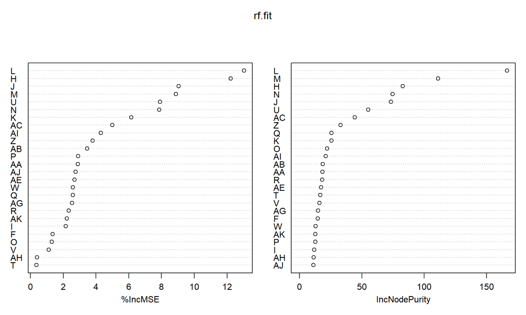

```r
varImpPlot(rf.fit)
```

랜덤포레스트 주요 인자 기준으로 모형을 재수립함

중요도 순서 :

- L : 한외여과 공정 0T - 10K Tank 총량 (kg)
- H : 회수공정 (X2) - RWP (kg)
- J : 회수공정 (X2) - RWP4 전도도
- M : 한외여과 공정 0T - UF 0T 10K 수율 (%)
- U : 한외여과 공정 Final T - 10K RP Peak 1 (%)
- N : 한외여과 공정 OT - 10K RP Peak 1 (%)

```r
rf.fit_best=randomForest(BB ~ L +
                           H +
                           J +
                           M +
                           U +
                           N, data=df_train,importance=T)

rf.fit_best
```

```
##
## Call:
##  randomForest(formula = BB ~ L + H + J + M + U + N, data = df_train,      importance = T)
##                Type of random forest: regression
##                      Number of trees: 500
## No. of variables tried at each split: 2
##
##           Mean of squared residuals: 5.478382
##                     % Var explained: 58.32
```

### Step15 모형 검증 및 최적화

실제 관측값을 회귀모형과 랜덤 포레스트 모형에 대입하여 예측값을 확인함

```r
lm_obs = df_test$BB #실제 관측값
lm_pred = predict(lm.fit_best,newdata=df_test) # 예측값
rf_pred = predict(rf.fit_best,newdata=df_test) # 예측값
```

각 모형의 MSE 를 확인함

MSE 확인 :

- 선형회귀 : 0.0787
- 랜덤포레스트 : 5.0016

```r
library(DescTools)
MSE(lm_pred, lm_obs)
```

```
## [1] 0.07873769
```

```r
MSE(rf_pred, lm_obs)
```

```
## [1] 5.001556
```

평균 제곱근(RMSE) 편차?

- 평균 제곱근 오차(Root Mean Square Error; RMSE)는 추정 값 또는 모델이 예측한 값과 실제 환경에서 관찰되는 값의 차이를 다룰 때 흔히 사용하는 측도임
- https://ko.wikipedia.org/wiki/%ED%8F%89%EA%B7%A0_%EC%A0%9C%EA%B3%B1%EA%B7%BC_%ED%8E%B8%EC%B0%A8

RMSE 확인 :

- 선형회귀 : 0.281
- 랜덤포레스트 : 2.236

```r
RMSE(lm_pred, lm_obs)
```

```
## [1] 0.2806024
```

```r
RMSE(rf_pred, lm_obs)
```

```
## [1] 2.236416
```

설명력(상관계수 제곱) 확인

- 선형회귀 R^2 : 99%
- 랜덤포레스트 R^2 : 58%

```r
(cor(lm_pred,lm_obs))^2
```

```
## [1] 0.9934742
```

```r
(cor(rf_pred,lm_obs))^2
```

```
## [1] 0.5815941
```

모델링에 활용된 인자 범위를 체크하고 불필요한 변수는 제거함

- 배치 번호 (변수 A) 제거

```r
df_range <- df_test %>%
  select(-A)
length(df_range)
```

```
## [1] 27
```

For 문

for (i in 1: xx) : 1 ~ xx에 숫자를 length 값으로 넣어줌

```r
print("Feature range")
```

```
## [1] "Feature range"
```

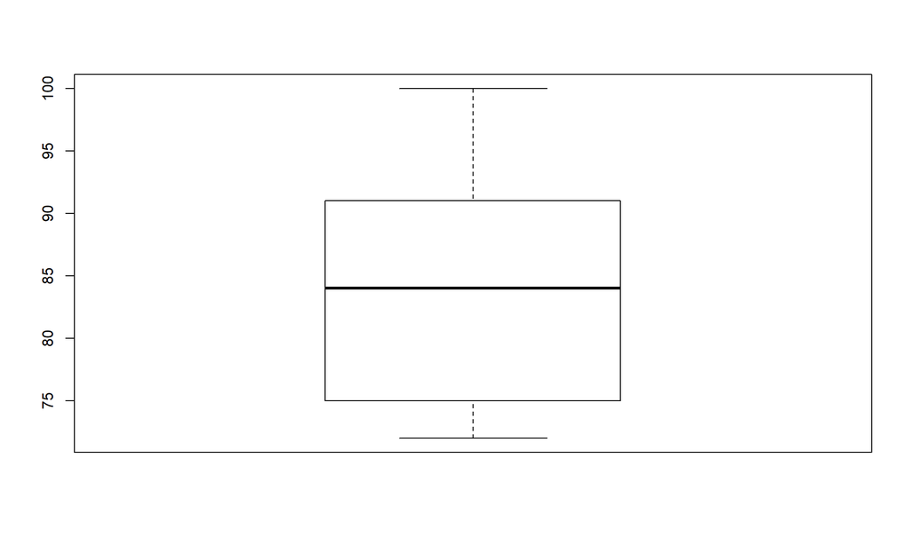

```
##   names lower upper
## 1     F    73    97
```

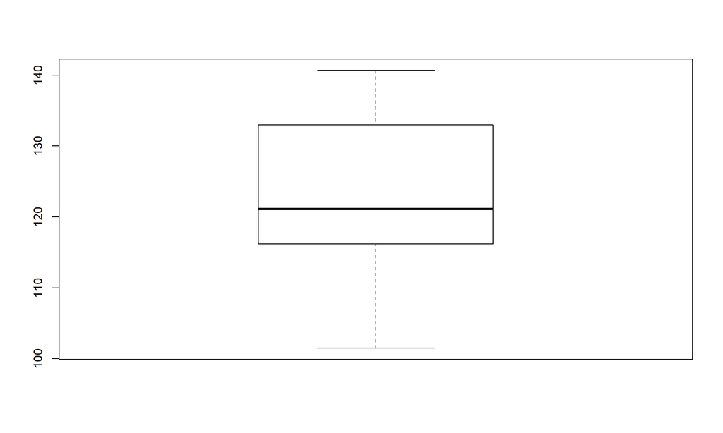

```
##   names lower upper
## 1     H 102.9 137.9
```

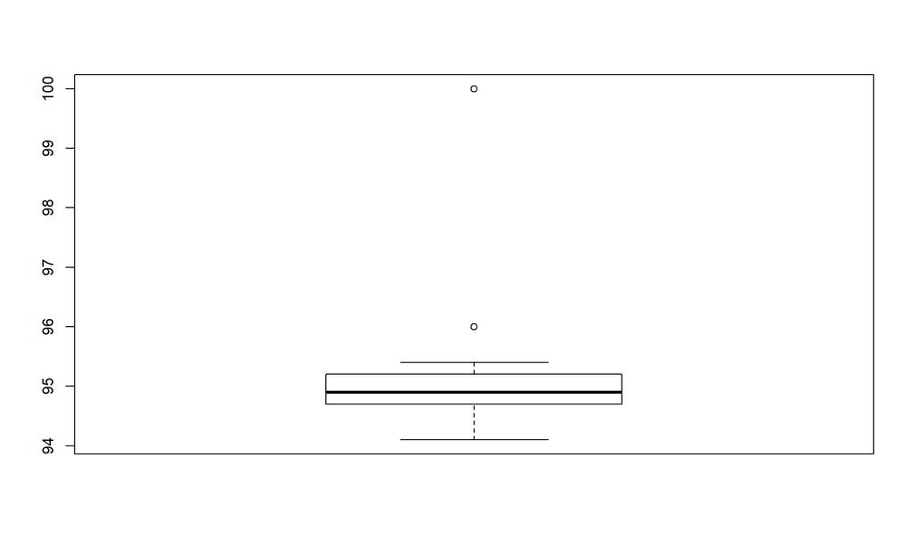

```
##   names lower upper
## 1     I  94.3  95.3
```

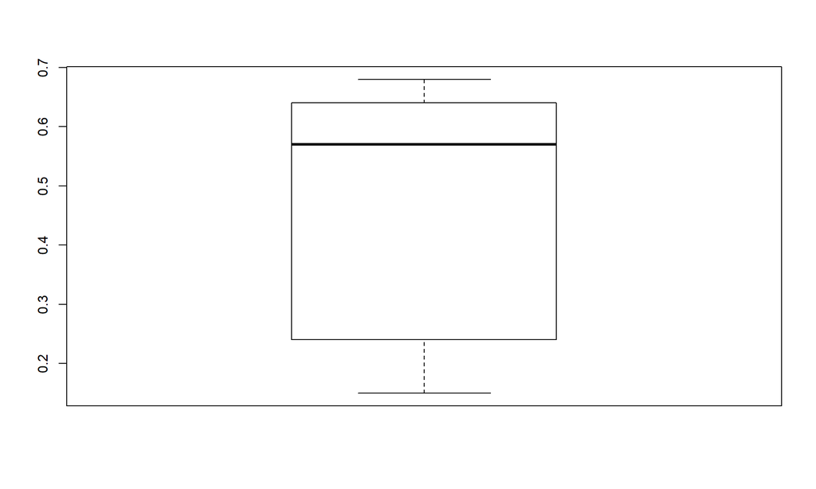

```
##   names lower upper
## 1     J  0.16  0.67
```

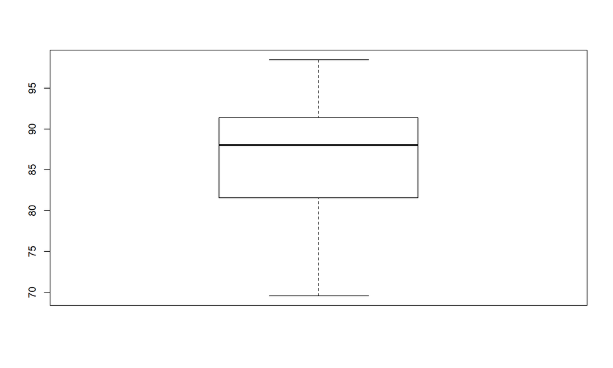

```
##   names lower  upper
## 1     K 71.22 97.768
```

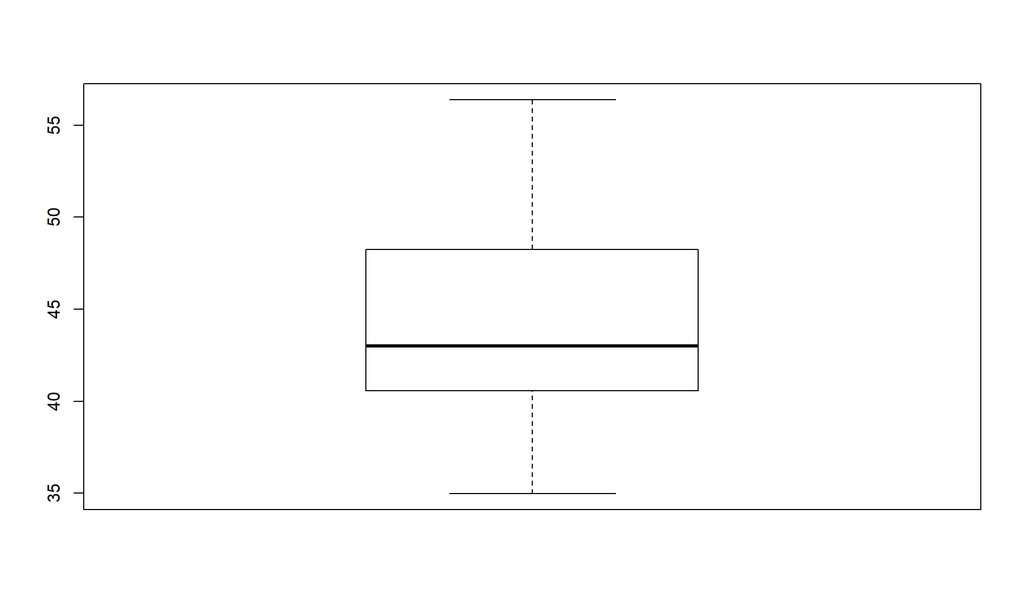

```
##   names  lower upper
## 1     L 35.334  53.9
```

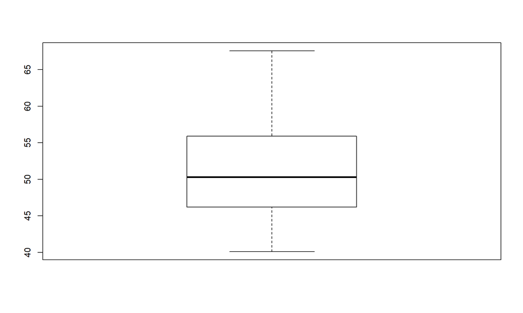

```
##   names    lower    upper
## 1     M 41.69872 63.01338
```

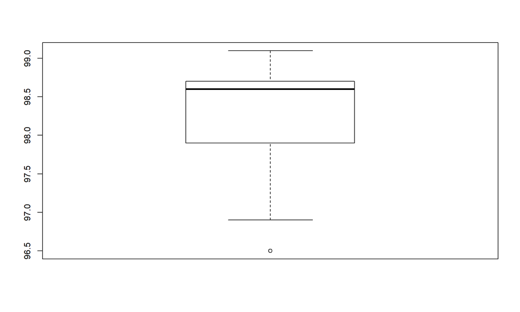

```
##   names lower upper
## 1     N  97.6    99
```

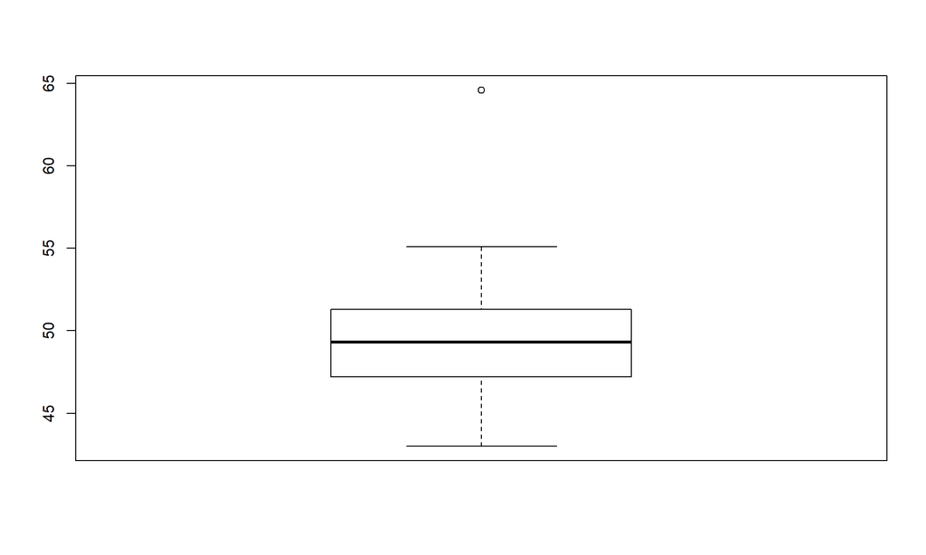

```
##   names lower upper
## 1     O  43.9  52.9
```

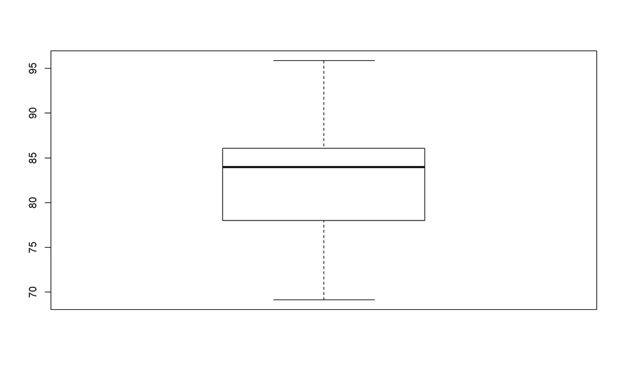

```
##   names  lower upper
## 1     P 70.224 92.61
```

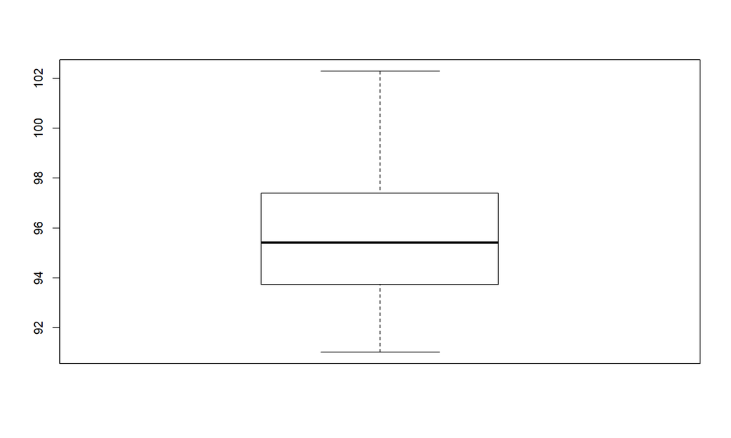

```
##   names    lower    upper
## 1     Q 91.64553 101.7799
```

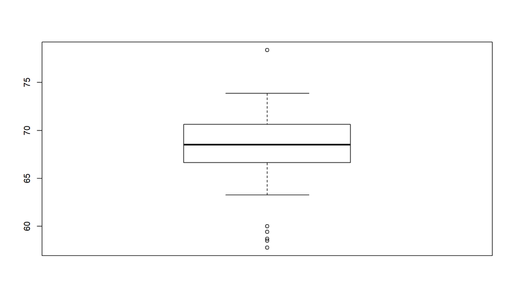

```
##   names  lower upper
## 1     R 64.711 72.98
```

[15 more figures not shown]

```
##   names    lower    upper
## 1    BB 65.21984 76.97297
```

```r
for( i in 1:27){
  A = df_range %>% filter(df_range[,i]>0) %>% .[,i]
  B = A[A>boxplot(A)$stats[1]&A<boxplot(A)$stats[5]] %>% range()
  print(data.frame(names=colnames(df_range)[i] ,lower=B[1],upper=B[2]))
}
```